# Spatial Mapping

## 0.1 Requirements for this lab

In this lab, you are required to use the skills learned from Module 12 to create a R Markdown where you need to map the three spatial datasheets with a scale bar, legends and a north arrow.

#### Please create a R Markdown file, set the output format as html_document or html_document2. Finally knit the R Markdown file into the HTML file.

#### Please use the data provided to conduct a **Spatial Mapping** based on the steps mentioned below.

- > Steps:
  > 1. Install and load required packages.
  > 2. Load and inspect the datasets.  
  >    *-* There are three datasets:  
  >    *(1)* US states  
  >    *(2)* Indiana watershed  
  >    *(3)* Place (Cities) in Indiana
  > 3. Select out the state Indiana and two cities “Carmel” and “Muncie”.  
  >    *-* Select Indiana from the “states” data.  
  >    *-* Select cities “Carmel” and “Muncie” from the “place” data.
  > 4. Plot a basic spatial mapping for the datasets of State Indiana, Indiana watershed and Indiana places.  
  >    *-* Without scale bar, north arrow etc.
  > 5. Plot a professional spatial mapping for the datasets of State Indiana,Indiana watershed and the two selected cities.  
  >    *-* With scale bar, legends for all items, north arrow.  
  >    *-* There are three legends: a legend for the polygon boundaries of Indiana and watershed in Indiana; a legend for the two cities with different filled colors; a legend for the watershed in Indiana with different filled colors.

#### Please name your file as *Yourname_12.3_Spatial Mapping.RMD*

#### Please knit your R Markdown file into a HTML file and submit the HTML file. Please have the codes and graphs displayed in your file.

## 0.2 A basic spatial map like this one

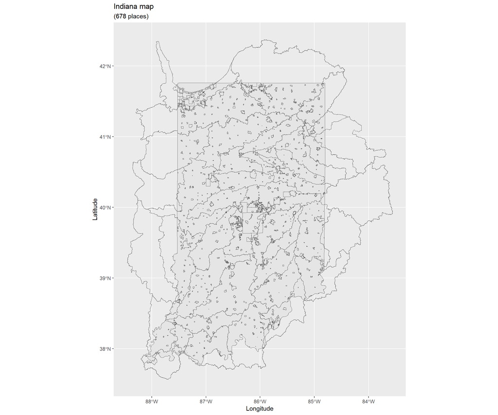

## 0.3 A professional spatial map like this one

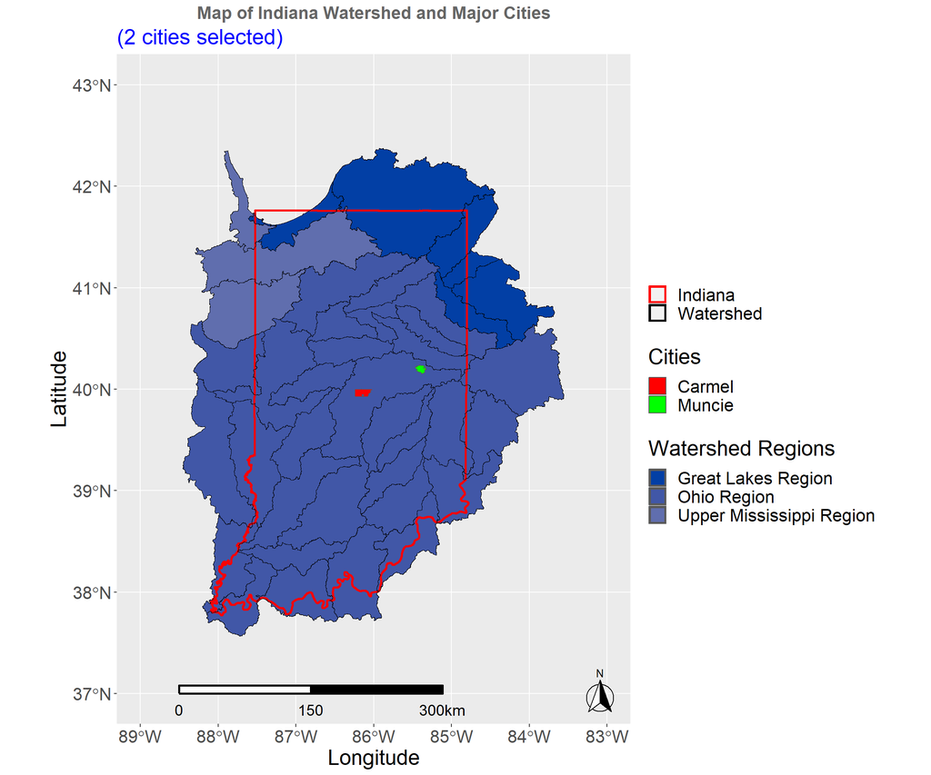